# Darren Hunt

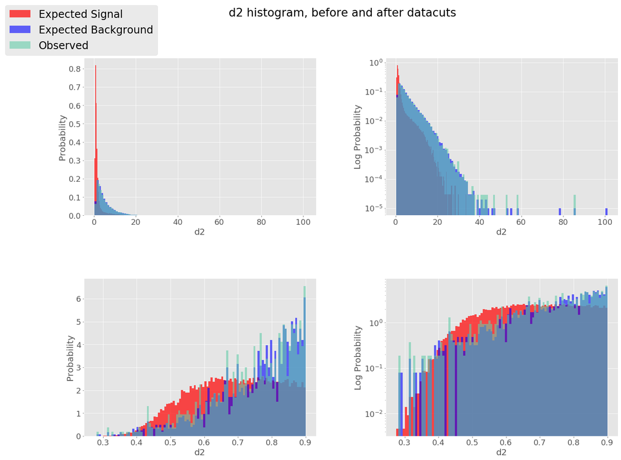

```
Expected Sigma : 1.5848
Observed Sigma : 1.5383
```

```python
d2Obs = data_slicer('d2',0.15,0.9,True)
four_hist('d2',highlum['d2'],d2Obs,"high")
sigma(d2,'d2')
obs_sigma(d2,d2Obs,'d2',highlum)
```

The ECF ratio parameter's sigma drops slightly when using the observed data. This one is important to observe the graphs more carefully for discussion. While the sliced data, which encapsulates most of the expected signal range, gets rid of some of the background, a few seemingly outlier values stick out beyond d2 = 40 (top graphs). Additionally, in the cut data, there appear to be more distinguished dips between the background shape and the observed shape. For a more in depth analysis, we might want to read the literature on what this could mean, if anything. Otherwise, this is not statistically significant.

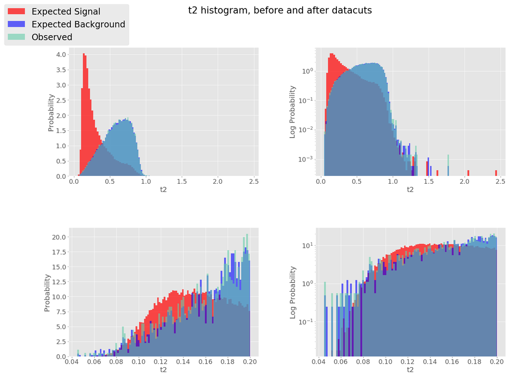

```
Expected Sigma : 1.5415
Observed Sigma : 1.4689
```

```python
t2Obs = data_slicer('t2',.009,0.2,True)
four_hist('t2',highlum['t2'],t2Obs,"high")
sigma(t2,'t2')
obs_sigma(t2,t2Obs,'t2',highlum)
```

The 2-subjettiness patterns follow similar findings as the d2 discussion previously. While the sigma drops slightly when looking at the observed data, there are some noticeable spikes and dips when comparing the observed versus background data. These may or may not be worth examining further. Otherwise, this is not statistically significant.

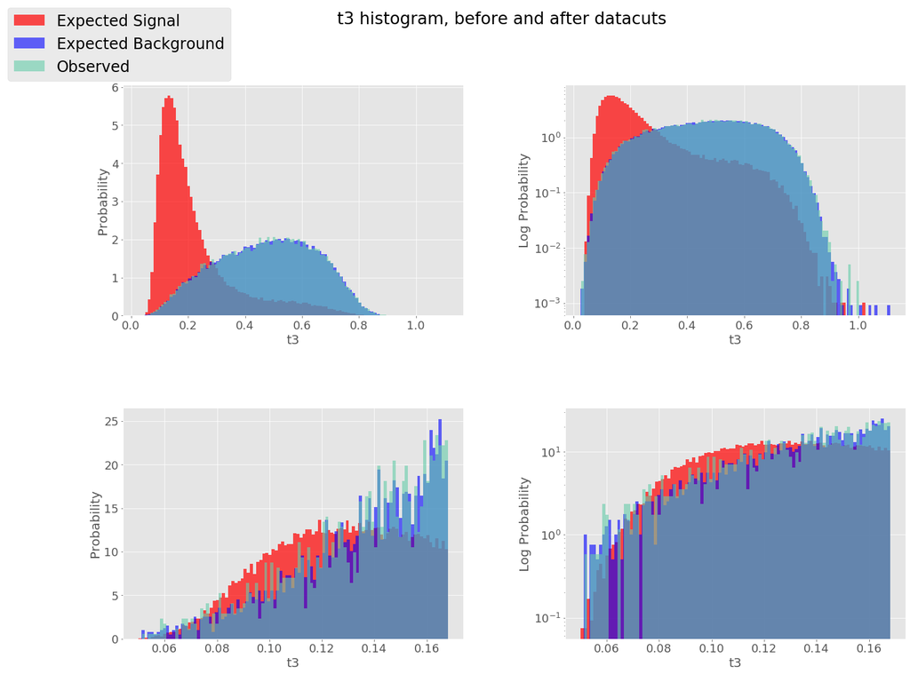

```
Expected Sigma : 1.8282
Observed Sigma : 1.7673
```

```python
t3Obs = data_slicer('t3',0.05,0.168,True)
four_hist('t3',highlum['t3'],t3Obs,"high")
sigma(t3,'t3')
obs_sigma(t3,t3Obs,'t3',highlum)
```

This follows the same pattern of discussion as previous. While the first row of graphs doesn't show much detail, once we cut the data, we can see more differences between the background and observed.

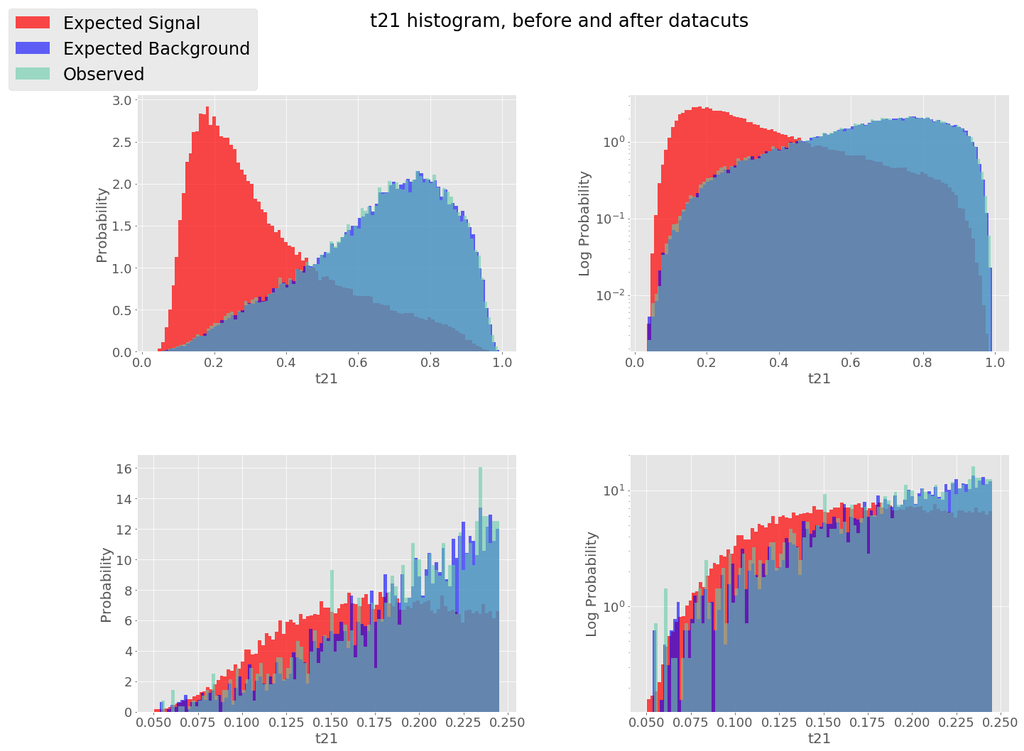

```
Expected Sigma : 1.3675
Observed Sigma : 1.3120
```

```python
t21Obs = data_slicer('t21',0.05,0.245,True)
four_hist('t21',highlum['t21'],t21Obs,"high")
sigma(t21,'t21')
obs_sigma(t21,t21Obs,'t21',highlum)
```

This follows the same discussion.

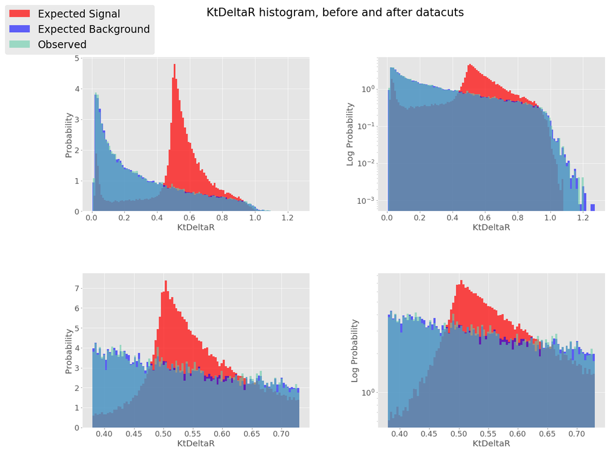

```
Expected Sigma : 0.8136
Observed Sigma : 0.8075
```

```python
KtDeltaRObs = data_slicer('KtDeltaR',0.38,0.73,True)
four_hist('KtDeltaR',highlum['KtDeltaR'],KtDeltaRObs,"high")
sigma(ktdr,'KtDeltaR')
obs_sigma(ktdr,KtDeltaRObs,'KtDeltaR',highlum)
```

The KtDeltaR graphs follow a similar discussion once again.

Summarizing the results of the sigma calculations and the plots, overall we do not see any statistically significant observations above $5\sigma $when using the expected versus observed data, nor does it improve after making any optimization cuts. The observed data largely follows the pattern of a typically expected background. For a statistical discovery to occur, a rare event that cannot be produced or attributed to the standard background data must be located. These datasets do not demonstrate such an event has occurred.

## Low luminosity data

Next, we repeat the previous graphs and sigma calculations for the same set of parameters, but for a dataset with low luminosity.

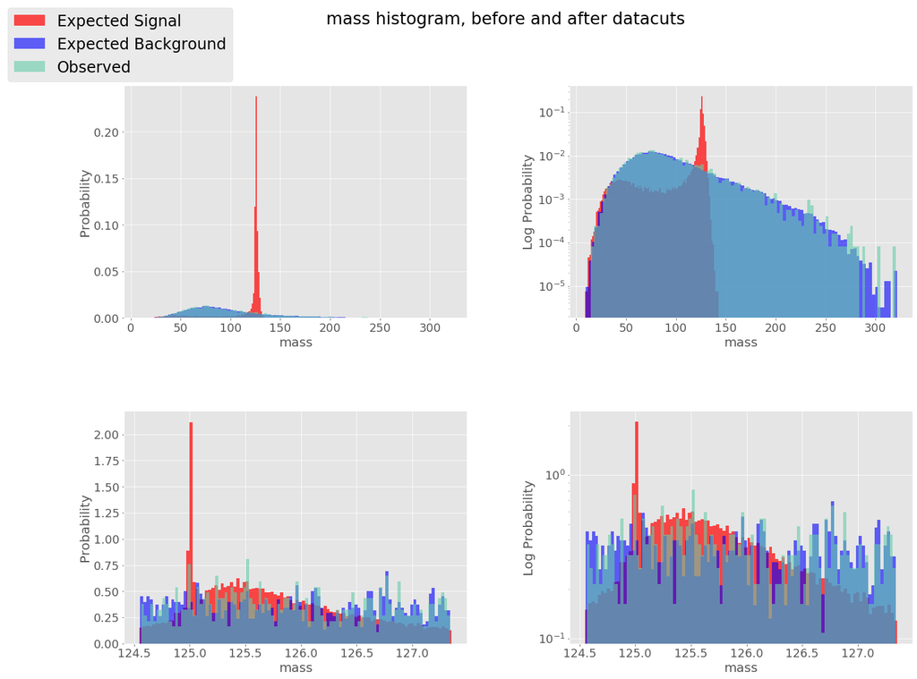

```
Expected Sigma : 3.0868
Observed Sigma : 2.7428
```

```python
lmassObs = data_slicer('mass',124.55,127.35,True)
four_hist('mass',lowlum['mass'],lmassObs,"high")
sigma(c3,'mass')
obs_sigma(c3,lmassObs,'mass',lowlum)
```

The observed sigma value for mass in the low luminosity dataset decreases by about 0.3 sigma. While the observed data generally appears to follow the expected background, there are some dips and spikes visible in the figure above. This is not statistically significant.

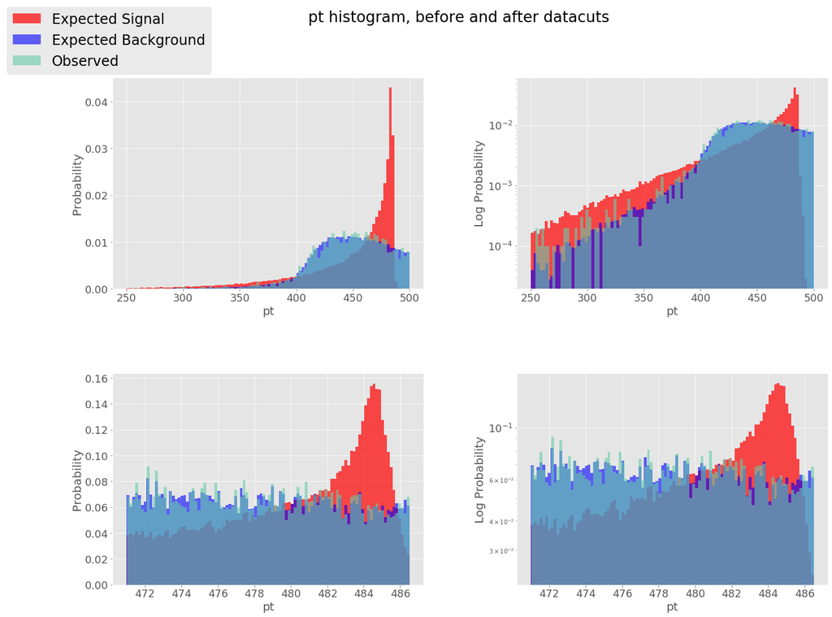

```
Expected Sigma : 0.7876
Observed Sigma : 0.7846
```

```python
lptObs = data_slicer('pt',471,486.5,True)
four_hist('pt',lowlum['pt'],lptObs,"high")
sigma(pt,'pt')
obs_sigma(pt,lptObs,'pt',lowlum)
```

Not much changes between the expected and observed for transverse momentum.

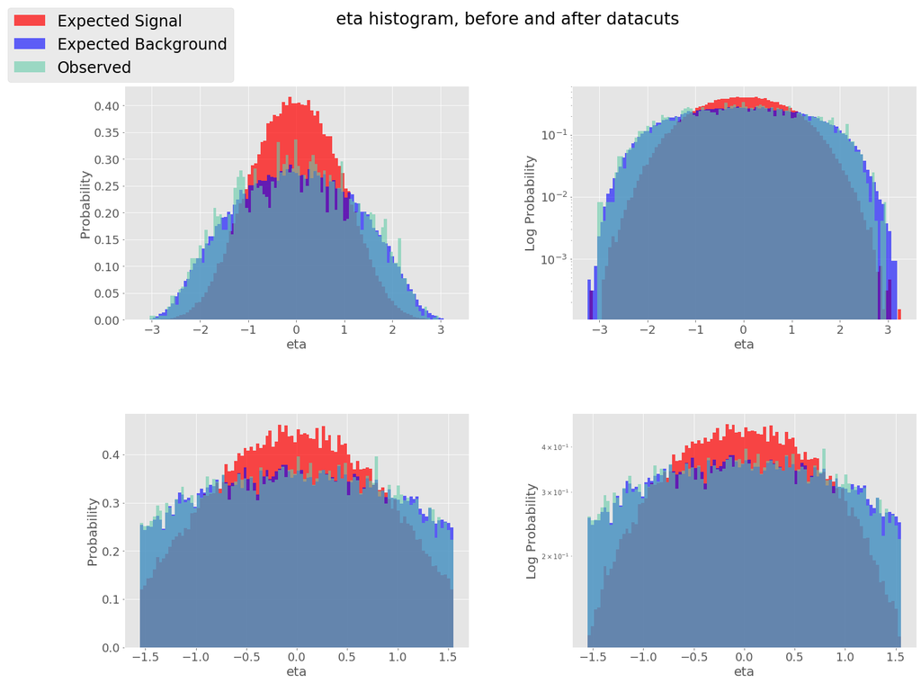

```
Expected Sigma : 3.6925
Observed Sigma : 2.4719
```

```python
letaObs = data_slicer('eta',-1.55,1.55,True)
four_hist('eta',lowlum['eta'],letaObs,"high")
sigma(eta,'eta')
obs_sigma(eta,letaObs,'eta',lowlum)
```

The significance drops for eta between the expected and observed datasets. In the observed, there is much less signal (a lot got cut out while I maximized the sigma value).

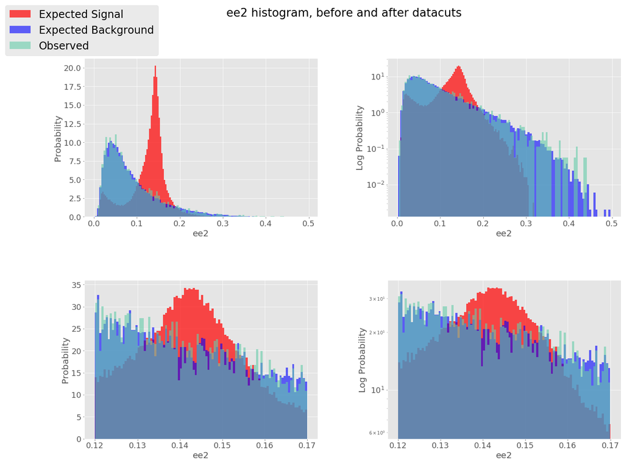

```
Expected Sigma : 1.0760
Observed Sigma : 1.0333
```

```python
lee2Obs = data_slicer('ee2',0.12,0.17,True)
four_hist('ee2',lowlum['ee2'],lee2Obs,"high")
sigma(ee2,'ee2')
obs_sigma(ee2,lee2Obs,'ee2',lowlum)
```

Not much changes in this cut of the 2nd ECF.

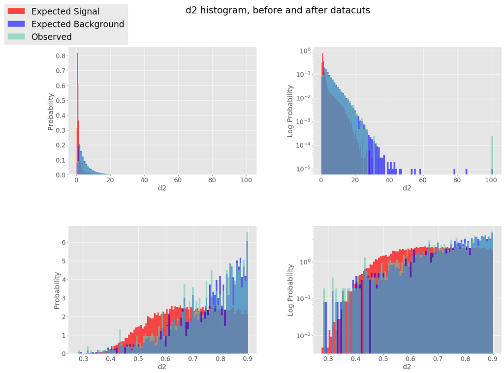

```
Expected Sigma : 1.5848
Observed Sigma : 1.6222
```

```python
ld2Obs = data_slicer('d2',0.15,0.9,True)
four_hist('d2',lowlum['d2'],ld2Obs,"high")
sigma(d2,'d2')
obs_sigma(d2,ld2Obs,'d2',lowlum)
```

Here, we finally see a very small increase in the significance between expected and observed for the ECF ratio parameter. The obesrved versus background has some noticeable spikes and dips in the cut graphs, so this might play a factor.

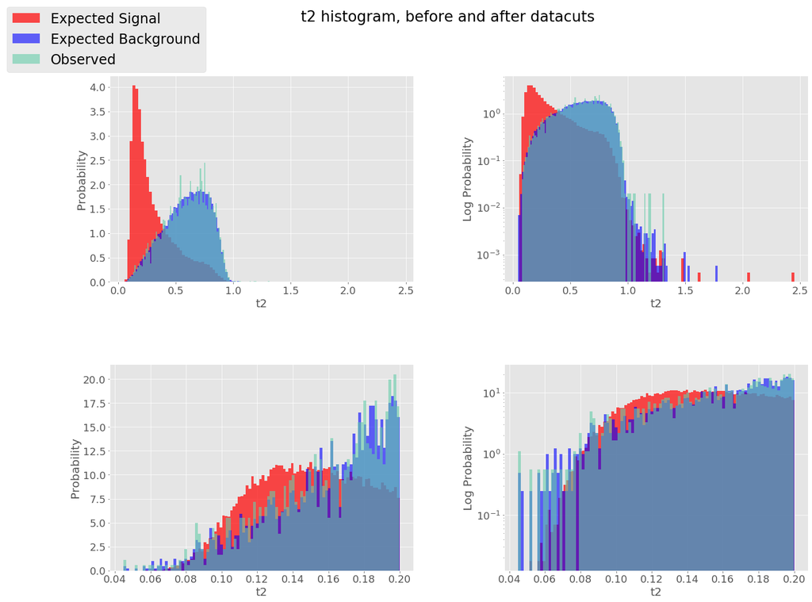

```
Expected Sigma : 1.5415
Observed Sigma : 1.5770
```

```python
lt2Obs = data_slicer('t2',.009,0.2,True)
four_hist('t2',lowlum['t2'],lt2Obs,"high")
sigma(t2,'t2')
obs_sigma(t2,lt2Obs,'t2',lowlum)
```

Similar to the previous discussion, the 2-Subjettiness parameter experiences a very small increase in sigma values.

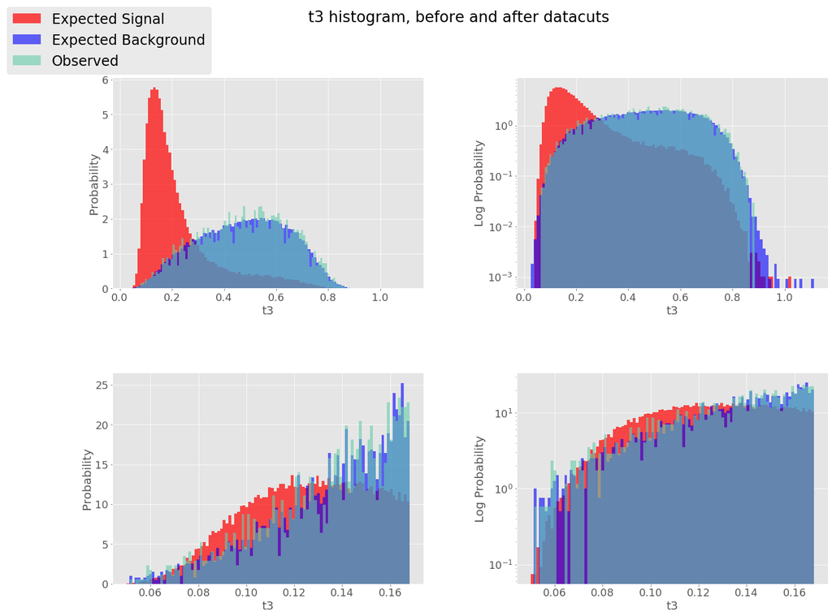

```
Expected Sigma : 1.8282
Observed Sigma : 1.8763
```

```python
lt3Obs = data_slicer('t3',0.05,0.168,True)
four_hist('t3',lowlum['t3'],lt3Obs,"high")
sigma(t3,'t3')
obs_sigma(t3,lt3Obs,'t3',lowlum)
```

Similar to the pattern of the previous discussion.

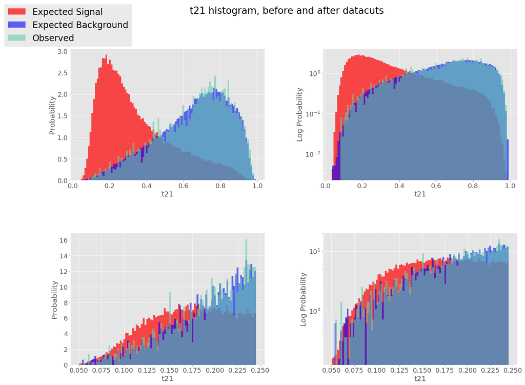

```
Expected Sigma : 1.3675
Observed Sigma : 1.3848
```

```python
lt21Obs = data_slicer('t21',0.05,0.245,True)
four_hist('t21',lowlum['t21'],lt21Obs,"high")
sigma(t21,'t21')
obs_sigma(t21,lt21Obs,'t21',lowlum)
```

Similar to the pattern of the previous discussion.

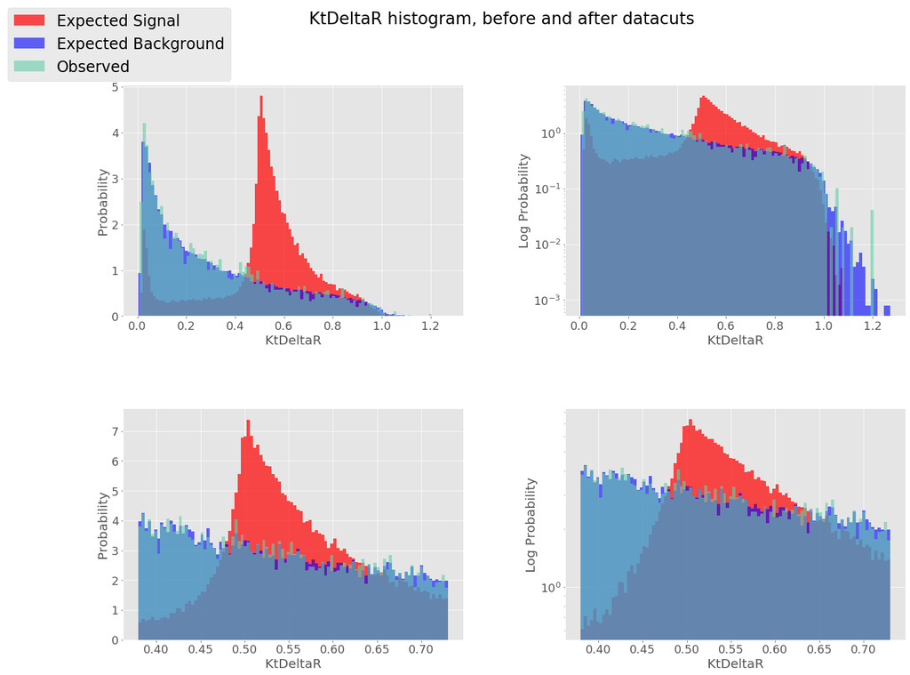

```
Expected Sigma : 0.8136
Observed Sigma : 0.8158
```

```python
lKtDeltaRObs = data_slicer('KtDeltaR',0.38,0.73,True)
four_hist('KtDeltaR',lowlum['KtDeltaR'],lKtDeltaRObs,"high")
sigma(ktdr,'KtDeltaR')
obs_sigma(ktdr,lKtDeltaRObs,'KtDeltaR',lowlum)
```

The KtDeltaR parameter stays roughly the same between the expected and observed.

Summarizing these results, for the most part, there are only minor changes (increases or decreases) between all of the cut parameters' observed sigmas versus expected sigma values. A few had slight increases in statistical significance, while a few had slight decreases. Overall, not much was remarkable in the sigma calculations. Could this be due to the fact that we are looking at the low momentum sample, where particle physics might not be as interesting (?) and might follow more typical noise background shapes?

## 95% Confidence level of the expected upper limit

```python
# expected 95% confidence level upper limit
print("Upper 95% bound, expected signal : "+str("{0:.3f}".format(np.percentile(higgs_dict,95))))
print("Upper 95% bound, expected background : "+str("{0:.3f}".format(np.percentile(qcd_dict,95))))

# observed 95% confidence level upper limit
print("Upper 95% bound, observed : "+str("{0:.3f}".format(np.percentile(lowlum,95))))
```

```
Upper 95% bound, expected signal : 440.117
Upper 95% bound, expected background : 430.261
Upper 95% bound, observed : 431.043
```

The expected signal has the highest upper bound, and the expected background has the lowest upper bound. The observed data is very close in value to the expected background. In general, for these datasets, we can attribute findings to the background. No statistically significant discovery was hidden in the low luminosity data.

## 1$\sigma$ uncertainty of the expected 95% upper limit

```python
# calculate 1 sigma uncertainty
# calculate each side separately to ensure it's symmetric
onesig = stats.norm.cdf(1)
onesigneg = stats.norm.cdf(-1)

upper = stats.poisson.ppf(onesig,(np.percentile(higgs_dict,95)))
lower = stats.poisson.ppf(onesigneg,(np.percentile(higgs_dict,95)))

plus = upper - (np.percentile(higgs_dict,95))
minus = (np.percentile(higgs_dict,95)) - lower

print("1-sigma expected signal uncertainty, upper : "+str("{0:.2f}".format(plus))+", Upper bound : "+str(upper))
print("1-sigma expected signal uncertainty, lower : "+str("{0:.2f}".format(minus))+", Lower Bound : "+str(lower))

upperbg = stats.poisson.ppf(onesig,(np.percentile(qcd_dict,95)))
lowerbg = stats.poisson.ppf(onesigneg,(np.percentile(qcd_dict,95)))

plusbg = upper - (np.percentile(qcd_dict,95))
minusbg = (np.percentile(qcd_dict,95)) - lower

print("1-sigma expected background uncertainty, upper : "+str("{0:.2f}".format(plusbg))+", Upper bound : "+str(upperbg))
print("1-sigma expected background uncertainty, lower : "+str("{0:.2f}".format(minusbg))+", Lower Bound : "+str(lowerbg))
```

```
1-sigma expected signal uncertainty, upper : 20.88, Upper bound : 461.0
1-sigma expected signal uncertainty, lower : 21.12, Lower Bound : 419.0
1-sigma expected background uncertainty, upper : 30.74, Upper bound : 451.0
1-sigma expected background uncertainty, lower : 11.26, Lower Bound : 410.0
```